```python
from datetime import datetime
```

```python
datetime.now().strftime("%Y-%m-%d/%H:%M")
```

```
'2021-03-08/12:22'
```

# 0. Reading in the data, creating `AnnData` object

We will only need the normalised, scaled and centered expression values, the cluster IDs, and the tSNE coordinates. We compile those into an `AnnData` object, for further use with ScanPy.

```python
import scanpy as sc
import anndata as ad
import pandas as pd
import numpy as np
```

```python
scaled = pd.read_csv("./data/210301_sl2_v3_scaled_matrix.tsv", sep="\t")
gene_names = pd.read_csv("./data/210301_sl2_v3_scaled_matrix_rownames.txt", sep="\t", header=None)
cluster_ids = pd.read_csv("./data/clusters_42_34_and_oddcells_reassigned.txt", header=None, sep=" ", index_col=0)
tsne = pd.read_csv("./data/single_cell_analysis_data_tsne_cell_embedding.tsv", sep="\t")
```

```python
adata = ad.AnnData(np.array(scaled).T)

adata.var.index = gene_names[0]
adata.obs.index = scaled.columns
adata.obs["annot"] = pd.Series(cluster_ids[1]).astype("category")
adata.obsm["X_tsne"] = np.array(tsne)
```

For continuity, let's also set the colors to the ones that were used in the paper.

```python
adata.uns["annot_colors"] = np.array(["#F8766D", "#F27C55", "#EB8335", "#E38900", "#DA8F00", "#CF9400", "#C49A00",
                                       "#B79F00", "#A9A400", "#99A800", "#86AC00", "#70B000", "#53B400", "#1DB700",
                                       "#00BA38", "#00BC56", "#00BE6D", "#00BF81", "#00C094", "#00C1A5", "#00C0B5",
                                       "#00BFC4", "#00BDD2", "#00BADF", "#00B6EB", "#00B1F5", "#00ABFD", "#06A4FF",
                                       "#619CFF", "#8893FF", "#A58AFF", "#BD81FF", "#D078FF", "#EC69EF",
                                       "#F564E3", "#FB61D7", "#FF61C8", "#FF63B9", "#FF66A8", "#FF6B96"])
```

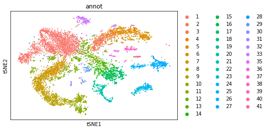

```python
sc.pl.tsne(adata, color="annot")
```

That looks like it worked. Let's also add cluster names so that the plots become a bit more interpretable. The names are a bit shortened so that they fit better on the plots, but still remain understandable:

```python
short_names = np.array(['archaeo 0', '2', '3', 'myo/pept 1',
                       'myo/pept 2', '6', '7', 'chob 1',
                       'chob 2', 'choano', 'apopyl', 'archaeo 1',
                       '13', '14', '15', '16',
                       '17', 'lopho', '19', '20',
                       'inc. pin. 1', 'inc. pin. 2', '23',
                       'metabo 1', 'metabo 2', '26',
                       'exc. pin. 1', 'exc. pin. 2', '29',
                       'neur. pin.', 'sclero', '32',
                       'meso 1', 'neur. cho.',
                       'meso 2', 'scleroph.', '38', 'amo',
                       'basopin.', 'meso 3'])

adata.obs["annot"].cat.categories = short_names
```

Now we will remove a couple of cells that caused problems.

```python
remove = ["TAAACCGGTGACAAAT-3", "TCTCTAAGTGCAACGA-3"]
keep_cells = [cell for cell in adata.obs.index if cell not in remove]
adata = adata[keep_cells]
```

# 2. Calculate PAGA based on the PCA

Unfortunately, we did not keep track of the random seed, so to ensure reproducibility of the figures in the paper, we will provide the principal components we used.

```python
pca = np.loadtxt("./data/210301_sl_PCs.txt")
adata.obsm["X_pca"] = pca
```

```python
sc.pp.neighbors(adata, n_neighbors=10, n_pcs=100)
sc.tl.paga(adata, groups="annot")
```

Let's have a look at the distribution of PAGA connectivity values; this will guide us in choosing appropriate thresholds.

```python
import matplotlib.pyplot as plt
```

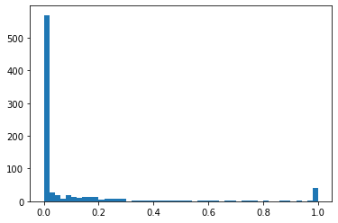

```python
tmp = adata.uns["paga"]["connectivities"].toarray()
paga = tmp[np.triu_indices(tmp.shape[0])]

fig, ax = plt.subplots()
ax.hist(paga, bins=50);
```

Clearly bimodal distribution, with a lot of 0s and quite some 1s. This suggests that a cutoff between 0.5-0.9 might be appropriate to reveal the base structure of the data. Our analysis suggested that 0.7 was a good cutoff.

# 3. Plotting

We will plot the tSNE using the colors of the main paper, the PAGA plot with the same structure as the tSNE, a PAGA plot colored by `#unique_marker_genes` per cluster, and a plot of gene expression over pseudotime, counting each cluster's distance from the archaeocyte cluster. We will keep referring to the tSNE embedding and the `"annot"` slot that we created above:

```python
cluster = "annot"
embedding = "X_tsne"
```

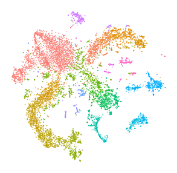

```python
cluster_cols = np.repeat("#FFFFFF", adata.shape[0])
for i, c in enumerate(adata.obs[cluster].cat.categories):
    cluster_cols[adata.obs[cluster] == c] = adata.uns[cluster + "_colors"][i]

fig, ax = plt.subplots(figsize=(5, 5))
ax.scatter(adata.obsm[embedding][:, 0], adata.obsm[embedding][:, 1], s=0.2, c=cluster_cols)
ax.axis('off');
```

## 3.2 PAGA graph

This is the default PAGA plot. There are multiple options to explore that could improve its aesthetics, but we want to put the cluster centers at the median positions of the cells of the tSNE cluster, so we need a custom solution. We will set the root to cluster 0, the bigger archaeocyte cluster:

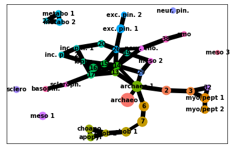

```python
sc.pl.paga(adata, threshold=0.7, layout="fr", root=0)
```

## 3.3 Custom PAGA graph with cluster IDs

To improve the readability of our custom plot:

- we will color all PAGA connections with a weight below 1.00 gray.
- we will scale line width linearly with the PAGA weight values. Since we place the PAGA cutoff at 0.7, the difference in line width between strong and weaker connections is not going to be so clear. We will rescale every value to exaggerate that, using 0.6 as the floor.

```python
threshold = 0.7
gray_threshold = 0.99
lwd_floor = 0.6
centers = adata.uns["paga"]["pos"]
connectivities = np.array(adata.uns["paga"]["connectivities"].todense())
```

```python
adata.obs["annot"].cat.categories
```

```
Index(['archaeo 0', '2', '3', 'myo/pept 1', 'myo/pept 2', '6', '7', 'chob 1',
       'chob 2', 'choano', 'apopyl', 'archaeo 1', '13', '14', '15', '16', '17',
       'lopho', '19', '20', 'inc. pin. 1', 'inc. pin. 2', '23', 'metabo 1',
       'metabo 2', '26', 'exc. pin. 1', 'exc. pin. 2', '29', 'neur. pin.',
       'sclero', '32', 'meso 1', 'neur. cho.', 'meso 2', 'scleroph.', '38',
       'amo', 'basopin.', 'meso 3'],
      dtype='object')
```

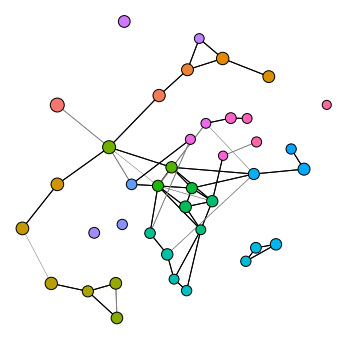

```python
fig, ax = plt.subplots(figsize=(6, 6))
ax.axis('off')
counts = np.zeros(adata.obs[cluster].cat.categories.shape)
for i, c in enumerate(adata.obs["annot"].cat.categories):
    cluster_points = adata.obsm[embedding][adata.obs[cluster] == c]
    centers[i] = np.median(cluster_points, axis=0)
    counts[i] = np.sum(adata.obs[cluster] == adata.obs[cluster].cat.categories[i])
for i, row in enumerate(connectivities):
    for j, _col in enumerate(row):
        if connectivities[i, j] > threshold:
            if threshold > 0:
                conn = (connectivities[i, j] - lwd_floor) / (1 - lwd_floor)
            else:
                conn = connectivities[i, j]
            if connectivities[i, j] > gray_threshold:
                con_col = "black"
            else:
                con_col = "gray"
            ax.plot(
                [centers[i, 0], centers[j, 0]],
                [centers[i, 1], centers[j, 1]],
                linewidth= (conn),
                c=con_col,
                zorder=0,
            )
ax.scatter(centers[:, 0], centers[:, 1], color=adata.uns["annot_colors"], s=25 * np.log(counts), zorder=1, edgecolors="black", marker="o");
```

## 3.4 Number of unique marker genes

To add the number of unique marker genes we will just do a maplotlib plot and not go back to scanpy. Just use the `c=` attribute of scatter plot, sicne that gives us easier colorbars

```python
no_marker_genes = pd.read_csv("/Users/papadopoulos/Documents/data/spongilla/unique_marker_gene_table.tsv", sep="\t")

# this list only has the clusters with #unique marker genes > 0; so we will have to create an empty
# vector of size 42 (initial number of clusters) and then select everything except positions 34, 42

tmp = np.zeros(42)
tmp[no_marker_genes.cluster_number-1] = no_marker_genes.unique_genes

keep = ~np.isin(np.arange(42), [33, 41])
unique_marker_genes_annot = tmp[keep]
```

We will plot the `log(#genes)` so that very rich clusters (like the archaeocytes) don't overwhelm our color bar. For the same reason we will cap `log(#genes)` at 4 to make it easier to see which nodes have lots of unique marker genes (and ignore the cells that have enormous amounts of UMGs):

```python
unique_capped = np.log(unique_marker_genes_annot + 1)
unique_capped[unique_capped > 4] = 4
```

No need to re-set thresholds or re-calculate cluster centers/point sizes, as we did that already

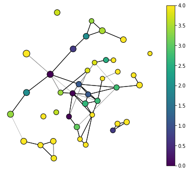

```python
fig, ax = plt.subplots(figsize=(7, 6))
for i, row in enumerate(connectivities):
    for j, _col in enumerate(row):
        if connectivities[i, j] > threshold:
            if threshold > 0:
                conn = (connectivities[i, j] - lwd_floor) / (1 - lwd_floor)
            else:
                conn = connectivities[i, j]
            if connectivities[i, j] > gray_threshold:
                con_col = "black"
            else:
                con_col = "gray"
            ax.plot(
                [centers[i, 0], centers[j, 0]],
                [centers[i, 1], centers[j, 1]],
                linewidth= (conn),
                c=con_col,
                zorder=0,
            )

plt.scatter(centers[:, 0], centers[:, 1], c=unique_capped, s=25 * np.log(counts), zorder=1, edgecolors="black", marker="o")
ax.axis('off')
plt.colorbar();
```

# 4. Plot gene expression along tree

To do that we will calculate diffusion maps and diffusion pseudotime, starting from the archaeocyte cluster. To avoid archaeocytes (which are severely overrepresented in the data) dominating the gene expression plots, we will subsample the archaeocyte clusters randomly.

First, let's fix the gene names: We will extract the Trinity ID of each gene from the index and save the index as `"long_name"`. We will then set the gene index to the Trinity ID, since this will make plotting easier down the line.

```python
adata.var["trinity"] = adata.var.index.str.split(" ").str[0]
adata.var["long_names"] = adata.var.index
adata.var_names = adata.var.trinity
```

Now we will set one cell in the `archaeocyte 0` cluster as the root, then calculate the diffusion map. The data is already normalised, log-transformed, scaled, and centered.

```python
adata.uns['iroot'] = np.flatnonzero(adata.obs['annot']  == 'archaeo 0')[0]

sc.tl.diffmap(adata)
sc.pp.neighbors(adata, n_neighbors=10, use_rep='X_diffmap')
sc.tl.dpt(adata)

adata.obs['distance'] = adata.obs['dpt_pseudotime']
```

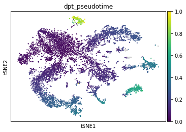

```python
sc.pl.tsne(adata, color="dpt_pseudotime")
```

```python
clusters, num_cells = np.unique(adata.obs.annot, return_counts=True)
clusters, num_cells
```

```
(array(['13', '14', '15', '16', '17', '19', '2', '20', '23', '26', '29',
        '3', '32', '38', '6', '7', 'amo', 'apopyl', 'archaeo 0',
        'archaeo 1', 'basopin.', 'choano', 'chob 1', 'chob 2',
        'exc. pin. 1', 'exc. pin. 2', 'inc. pin. 1', 'inc. pin. 2',
        'lopho', 'meso 1', 'meso 2', 'meso 3', 'metabo 1', 'metabo 2',
        'myo/pept 1', 'myo/pept 2', 'neur. cho.', 'neur. pin.', 'sclero',
        'scleroph.'], dtype=object),
 array([ 176,  146,  133,  252,  168,   88,  421,  184,   71,  142,   91,
         283,   47,  107,  604,  630,   49,  220, 2348,  857,   60,  241,
         452,  144,  316,   66,   51,   73,   49,  252,   57,   27,  100,
         178,  486,  275,   48,   71,  109,   32]))
```

```python
adata.shape
```

```
(10104, 39562)
```

```python
archeo_id = adata.obs.index[adata.obs.annot == "archaeo 0"]
remove = np.random.choice(len(archeo_id), size=len(archeo_id) - 400, replace=False)
remove_id = archeo_id[remove]
keep_cells = np.array([cell for cell in adata.obs.index if cell not in remove_id])
adata = adata[keep_cells]

archeo_id = adata.obs.index[adata.obs.annot == "archaeo 1"]
remove = np.random.choice(len(archeo_id), size=len(archeo_id) - 400, replace=False)
remove_id = archeo_id[remove]
keep_cells = np.array([cell for cell in adata.obs.index if cell not in remove_id])
adata = adata[keep_cells]
```

```python
adata.shape
```

```
(7699, 39562)
```

```python
clusters, num_cells = np.unique(adata.obs.annot, return_counts=True)
clusters, num_cells
```

```
(array(['13', '14', '15', '16', '17', '19', '2', '20', '23', '26', '29',
        '3', '32', '38', '6', '7', 'amo', 'apopyl', 'archaeo 0',
        'archaeo 1', 'basopin.', 'choano', 'chob 1', 'chob 2',
        'exc. pin. 1', 'exc. pin. 2', 'inc. pin. 1', 'inc. pin. 2',
        'lopho', 'meso 1', 'meso 2', 'meso 3', 'metabo 1', 'metabo 2',
        'myo/pept 1', 'myo/pept 2', 'neur. cho.', 'neur. pin.', 'sclero',
        'scleroph.'], dtype=object),
 array([176, 146, 133, 252, 168,  88, 421, 184,  71, 142,  91, 283,  47,
        107, 604, 630,  49, 220, 400, 400,  60, 241, 452, 144, 316,  66,
         51,  73,  49, 252,  57,  27, 100, 178, 486, 275,  48,  71, 109,
         32]))
```

Define the paths through the graph:

```python
paths = [
    ('choanocyte', ['archaeo 0', 'archaeo 1', '6', '7', 'chob 1', 'chob 2', 'choano', 'apopyl']),
    ('myopeptidocyte', ['archaeo 0', 'archaeo 1', '3', 'myo/pept 1', 'myo/pept 2']),
    ('incurrent pinacocytes', ['archaeo 0', 'archaeo 1', '19', '20', 'inc. pin. 1', 'inc. pin. 2']),
    ('excurrent pinacocytes', ['archaeo 0', 'archaeo 1', '13', '15', '26', 'exc. pin. 1', 'exc. pin. 2'])
]
```

```python
adata.var.index
```

```
Index(['c100-g1', 'c100000-g1', 'c100000-g3', 'c100001-g1', 'c100001-g3',
       'c100002-g1', 'c100003-g1', 'c100003-g2', 'c100004-g1', 'c100005-g1',
       ...
       'c99990-g1', 'c99991-g1', 'c99993-g1', 'c99993-g3', 'c99993-g4',
       'c99994-g1', 'c99995-g1', 'c99997-g1', 'c99997-g2', 'c99999-g1'],
      dtype='object', name='trinity', length=39562)
```

```python
gene_ids = [
"c92270-g1",
"c41805-g1",
"c101003-g1",
"c100975-g1",
"c103870-g1",
"c99613-g1",
"c110366-g1",
"c97076-g1",
"c98839-g2",
"c98349-g1",
"c103215-g2",
"c102802-g2",
"c79401-g1",
"c101683-g1",
"c79439-g1",
"c102195-g1",
"c103865-g1",
"c100676-g1",
"c103990-g2",
]

indices = [np.where(adata.var.index.str.contains(gene))[0][0] for gene in gene_ids]

gene_names = adata.var.index[indices]
```

Cap maximum expression values so that one gene doesn't dominate the expression plots, and save this object separately so we can go back and use different cut-offs:

```python
thresholded = adata.copy()
thresholded.X[thresholded.X > 4] = 4
```

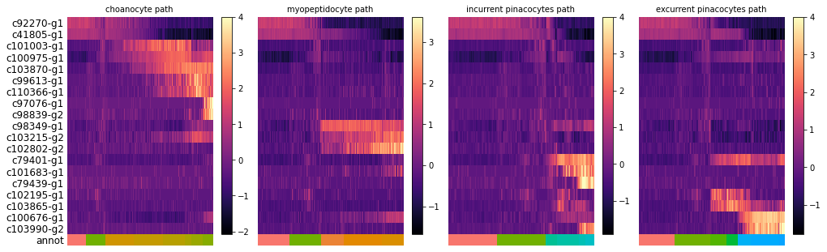

```python
fig, axs = plt.subplots(ncols=4, figsize=(15, 6), gridspec_kw={'wspace': 0.05, 'left': 0.12})
plt.subplots_adjust(left=0.05, right=0.98, top=0.82, bottom=0.2)
for ipath, (descr, path) in enumerate(paths):
    _, data = sc.pl.paga_path(
        thresholded, path, gene_ids,
        show_node_names=False,
        ax=axs[ipath],
        ytick_fontsize=12,
        left_margin=0.15,
        n_avg=10,
        annotations=[],
        show_yticks=True if ipath==0 else False,
        show_colorbar=True,
        color_map='magma',
        groups_key='annot',
        use_raw=False,
        color_maps_annotations={'distance': 'viridis'},
        title='{} path'.format(descr),
        return_data=True,);
```